# Les fonctions (partie 1)

Une fonction est une partie d'un traitement que l'on veut pouvoir réutiliser. Elle peut avoir des paramètres qui peuvent être des indications sur le traitement à effectuer. Elle peut retourner un ou plusieurs résultats.

## A Fonctions sans paramètre et sans résultat.

- Une fonction qui affiche "Bonjour"

```python
def afficheBonjour(): # définition de la fonction
    print("Bonjour!")
```

```python
afficheBonjour() # Appel de la fonction
```

- Une fonction qui trace un angle droit

```python
def angle_droit():   # Définition de la fonction
    forward(100)
    left(90)
    forward(100)
```

```python
from turtle import *
angle_droit()        # Appel de la fonction
exitonclick()
```

**Ex 1:** Faire une fonction qui affiche 10 fois "bonjour"

**Ex 2:** Représenter un escalier de 10 marches utilisant la fonction angle_droit()

## B Fonctions avec paramètres et qui ne retourne pas de résultat

```python
def ditBonjour(prenom):
    print("Bonjour ",end= "")
    print(prenom)
```

```python
ditBonjour("Marc")
```

Dans notre fonction angle_droit(), la longueur est fixée à 100 pixels.  
Pour dessiner des angles droits de longueur quelconque, on peut ajouter un paramètre à notre fonction.

```python
def angle_droit(x):   # Définition de la fonction
    forward(x)
    left(90)
    forward(x)
```

```python
angle_droit(20)
exitonclick()
```

**Ex 3:** Faire un programme qui représente un escalier à 10 marches avec des marches de plus en plus grandes en utilisant la fonction angle_droit(x) où x est la longueur(/hauteur) de la marche.

**Ex 4:** Faire une fonction carre(x, y, n) qui représente un carré dont le coin inférieur droit est en position (x, y) et le côté est de n pixels.

**Ex 5:** Représentation de la face d'un dé  
Executer le code suivant :

```python
# Carré extérieur
up()
goto(50, -50)
down()
for _ in range(4):
    left(90)
    forward(100)
# Point central
up()
goto(10, -10)
down()
begin_fill()
for _ in range(4):
    left(90)
    forward(20)
end_fill()
# Point inférieur droit
up()
goto(40, -40)
down()
begin_fill()
for _ in range(4):
    left(90)
    forward(20)
end_fill()
# point supérieur gauche
up()
goto(-20, 20)
down()
begin_fill()
for _ in range(4):
    left(90)
    forward(20)
end_fill()
ht()
exitonclick()
```

Refaire ce programme en utilisant la fonction carre(x,y,n) et une autre fonction carre_rempli(x,y,n) qui dessine un carré noir.

**Ex 6** : Faire une fonction poisson(x, y, taille, couleur) où (x,y) correspond à la position du poisson, taille sa longueur...  
Exemple: poisson(50, 50, 200, 'red')

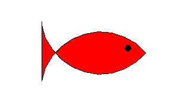

**Ex 7:** Faire un programme pour représenter la figure suivante

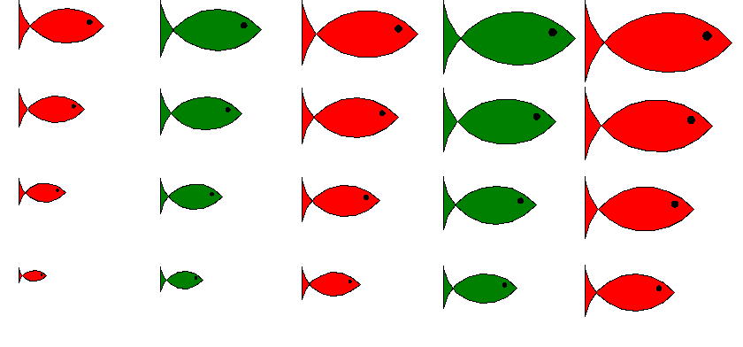

## C Fonctions avec paramètres qui renvoient un résultat.

```python
def maximum(x,y):
    if x>y:
        return x
    else:
        return y
```

```python
print(maximum(2,3))
```

**Ex 8:** Définir une fonction test_Pythagore qui prend trois entiers a, b et c en arguments et renvoie un booléen indiquant si $a^2 + b^2 = c^2$

**Ex 9:** Définir une fonction valeur_absolue qui prend un entier en argument et renvoie sa valeur absolue.

**Ex 10:** Faire une fonction qui prend en paramètre une chaine de caractères et qui renvoie le nombre de a  
dans cette chaine.

remarques :

- la fonction len(chaine) renvoie le nombre de caractères de la chaine
- mot[0] est le premier caractère de la chaine de caractère mot